# Final

Elmer Calel

16/5/2020

### Instrucciones:

- Resolver cada uno de los problemas.
- El primer problema es una prueba realizada por un banco del sistema para evaluar a los aspirantes a un cargo dentro de esa institución. Resolverlo utilizando R o equivalente.
- En el segundo problema hacer lo que se solicita, efectuar anova y análisis post-hoc si fuera necesario.
- Dejar constancia de cada uno de los problemas y enviar archivo csv para el primer problema y un pdf para la soluciones de ambos.

```r
# Librerías
library(readxl)
library(ggpubr)
library(MVN)
library(biotools)
library(car)
library(lsr)
library(readr)
library(tidyverse)
```

```r
library(ggcorrplot)
library(corrplot)
library(factoextra)
library(FactoMineR)
library(pROC)
```

## Problema 1

### Manipulación de los datos

Se acrga el set de datos de entrenamiento para el modelo.

```r
Base_entrenamiento <- read_csv("../Data/Base_entrenamiento.csv")
```

Se excluyen las variables que no generan valor al análisis.

```r
Base_entrenamiento.data <- Base_entrenamiento %>%
  select(-cp_inicial_menos_saldo,
         -cp_inicial_menos_saldo,
         -cp_cuotas_falta,
         -cp_nro_cuota,
         -cp_valor_inicial,
         -cp_cuota_sobre_saldo,
         -cp_saldo_sobre_inicial,
         -cp_esta_cuota_otro,
         -cp_porc_valorcuot_ing,
         -cp_saldo,
         -cp_cuota_sobre_inicial,
         -cp_porc_saldo_ing,
         -cp_valor_cuota,
         -banca_completa,
         -segmentoestructural,
         -subsegmentoestructural,
         -y_auto_cura,
         -llave)
```

### PCA para obtener las variables el modelo

Se procede a relizar un análisis de componentes principales para determinar cuáles son las variables que generan valor al análisis.

[figure not shown]

```r
ggcorrplot(cor(Base_entrenamiento.data), hc.order = T, type = "lower")
```

[figure not shown]

```r
pca_Base_entrenamiento <- PCA(Base_entrenamiento.data, graph = F)

var <- get_pca_var(pca_Base_entrenamiento)

corrplot(var$cos2, is.corr = F)
```

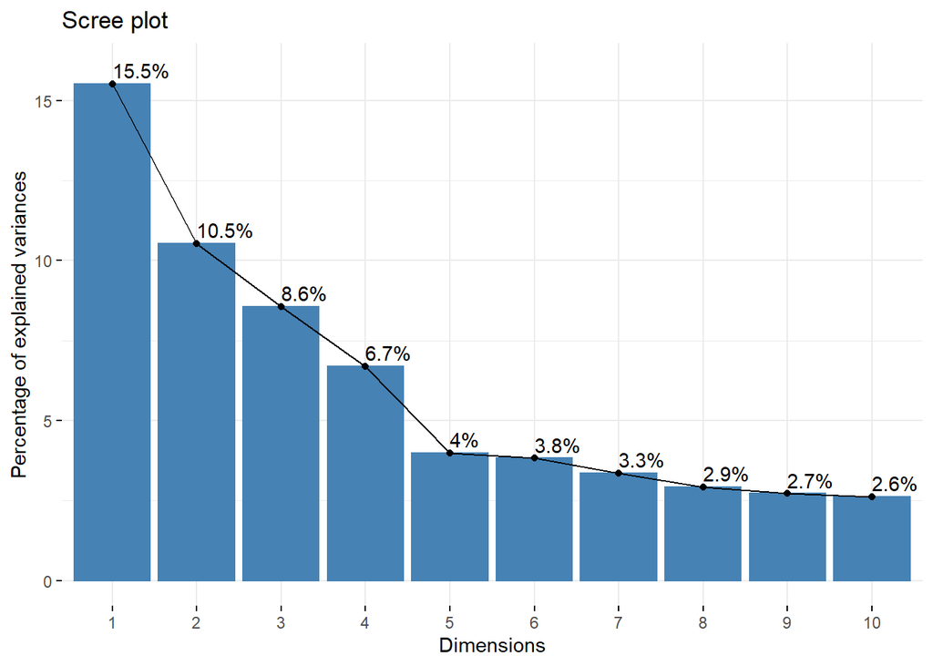

```r
fviz_screeplot(pca_Base_entrenamiento, addlabels = T, ylim =c (0, 16))
```

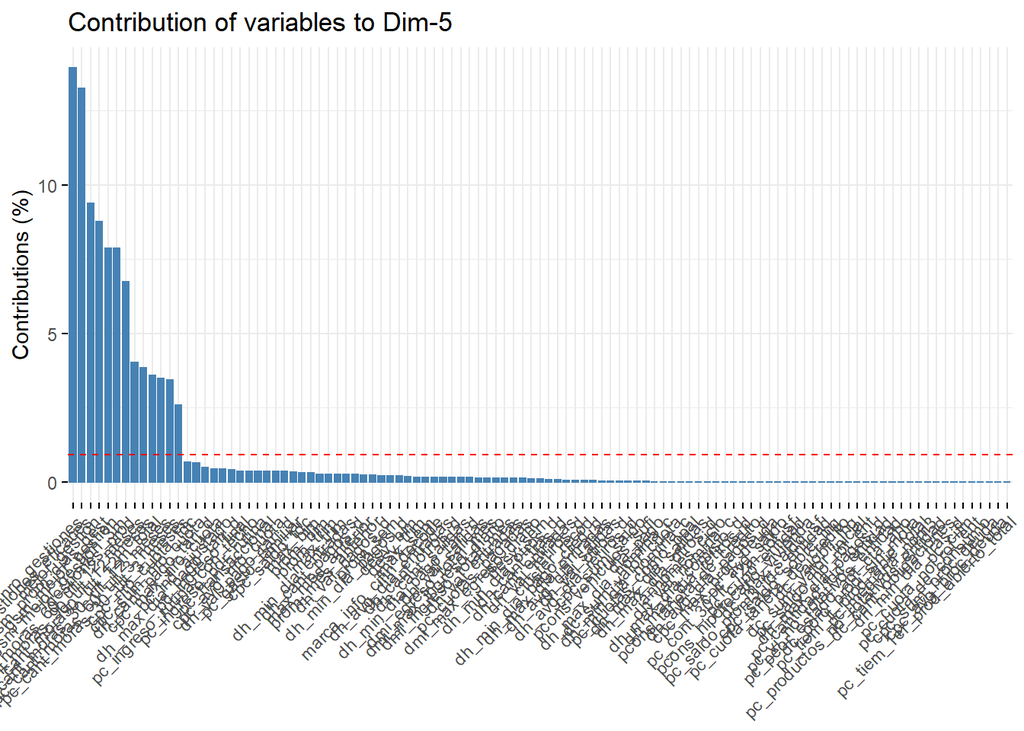

```r
fviz_contrib(pca_Base_entrenamiento, choice = "var", axes = 5)
```

Del análisis anterior, se determinó que para el modelo se utilizaránr solo las siguientes variables:

- nro_gestiones
- gestiones_eficaces
- mejor_gestion
- gsm_prom_dias_gest
- gsm_mejor_gestion_3m
- gsm_mejor_gestion
- gestiones_prod
- pc_cant_moras_60_ult_12_meses
- pc_cant_moras_90_ult_12_meses
- pc_cant_mora90_ult_12m_total
- pc_cant_moras_30_ult_12_meses
- pc_cant_moras_60_ult_3_meses
- pc_cant_moras_30_ult_3_meses

### Construcción del modelo

```r
# explorando variable respuesta
prop.table(table(Base_entrenamiento$y_auto_cura))
```

```
##
##         0         1
## 0.3073571 0.6926429
```

#### Regresión logística

Dado al estudio se construirá un modelo de regresión logística porque se trata de estimar la probabilidad de ocurrencia de un evento binario.

Construcción del modelo:

```r
modelo <- glm(Base_entrenamiento$y_auto_cura~nro_gestiones+
              gestiones_eficaces+
              mejor_gestion+
              gsm_prom_dias_gest+
              gsm_mejor_gestion_3m+
              gsm_mejor_gestion+
              gestiones_prod+
              pc_cant_moras_60_ult_12_meses+
              pc_cant_moras_90_ult_12_meses+
              pc_cant_mora90_ult_12m_total+
              pc_cant_moras_30_ult_12_meses+
              pc_cant_moras_60_ult_3_meses+
              pc_cant_moras_30_ult_3_meses,
            data = Base_entrenamiento.data,
            family = binomial)
```

Cálculo de la variable respuesta:

```r
pred_p <- predict(modelo, type="response")
head(pred_p, 10)
```

```
##         1         2         3         4         5         6         7         8
## 0.6512885 0.7157082 0.7460691 0.7460691 0.7460691 0.7460691 0.7460691 0.7460691
##         9        10
## 0.7460691 0.7460691
```

Conversión de la probabilidad de clasificación:

```r
pred <- ifelse(pred_p > 0.5,1,0)
sum(pred)
```

```
## [1] 13047
```

Precisión del modelo:

```r
# Precisión
precision <- mean(Base_entrenamiento$y_auto_cura == pred)
precision
```

```
## [1] 0.698
```

```r
#Error
1 - precision
```

```
## [1] 0.302
```

Matriz de confusión:

```r
conf <- table(Base_entrenamiento$y_auto_cura, pred, dnn = c("Actual", "Predicho"))
conf
```

```
##       Predicho
## Actual    0    1
##      0  514 3789
##      1  439 9258
```

Gráfica de la matriz de confusión:

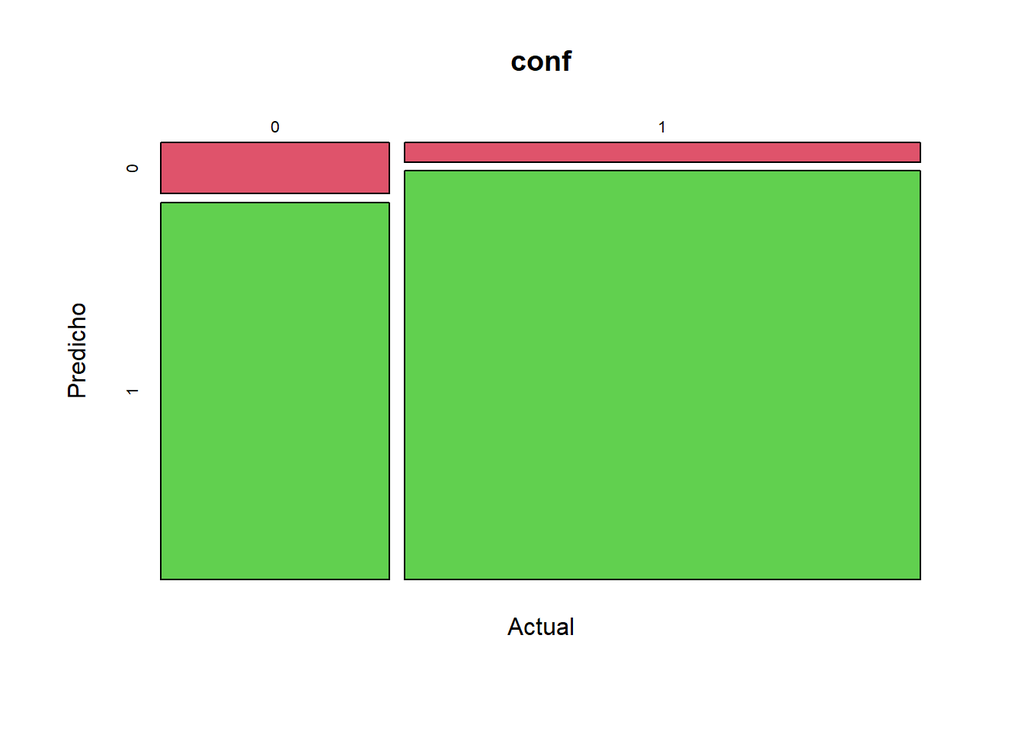

```r
mosaicplot(conf, col = 2:4)
```

Curva ROC y área bajo la curva:

```r
ROC <- roc(Base_entrenamiento$y_auto_cura, pred)
```

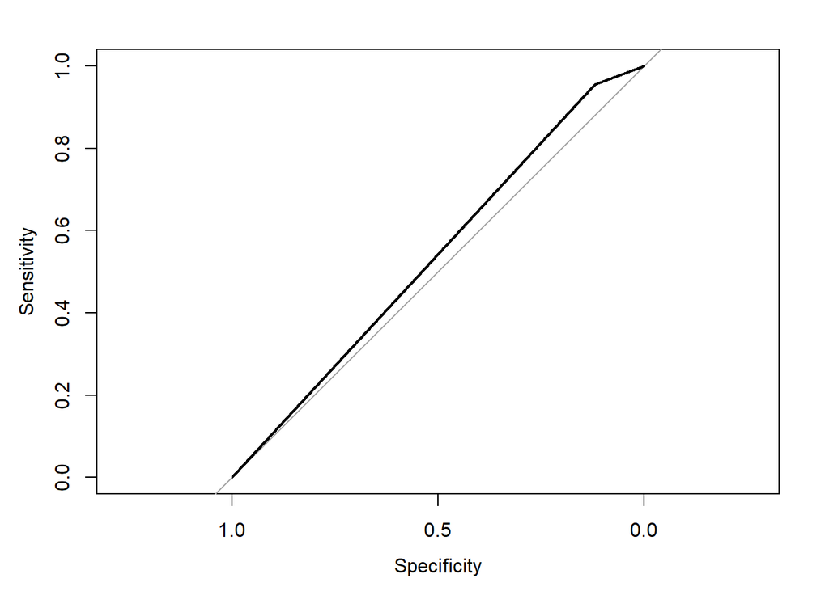

```r
plot(ROC)
```

```r
auc(ROC)
```

```
## Area under the curve: 0.5371
```

#### Probando el modelo

Se carga el set de datos para probar el modelo y se exporta el resultado a un archivo csv.

```r
Base_prueba <- read_csv("../Data/Base_prueba.csv")
Base_prueba <- Base_prueba %>%
  select("nro_gestiones",
         "gestiones_eficaces",
         "mejor_gestion",
         "gsm_prom_dias_gest",
         "gsm_mejor_gestion_3m",
         "gsm_mejor_gestion",
         "gestiones_prod",
         "pc_cant_moras_60_ult_12_meses",
         "pc_cant_moras_90_ult_12_meses",
         "pc_cant_mora90_ult_12m_total",
         "pc_cant_moras_30_ult_12_meses",
         "pc_cant_moras_60_ult_3_meses",
         "pc_cant_moras_30_ult_3_meses",
         "llave")

pred_p <- predict(modelo, Base_prueba[,-14])
pred <- ifelse(pred_p > 0.5,1,0)
Base_prueba$probabilidad  <- pred_p
Base_prueba$auto_cura <- pred

write_csv(Base_prueba[, 14:16], "../Data/Base_prueba_evaluado.csv")
```

## Problema 2

Realizar una análisis manova para las 5 variables del problema 15.7.2 del libro de cuadras, cada columna es una variable biometrica. Los factores son el sexo y la localidad.

Se tienen medidas de 5 variables biométricas sobre 6 especies de coleópteros del género Timarcha encontradas en 8 localidades distintas.

Las medidas (en mm.) son:

X1 = longitud Prognoto, X2 = diametro máximo prognoto, X3 = base prognoto, X4 = longitutd. Èlitros, X5 = diametro máximo Èlitros.

```r
escarab <- read_excel("../Data/escarab.xlsx")
head(escarab, 3)
```

```
## # A tibble: 3 x 7
##      X1    X2    X3    X4    X5 Sexo  Localidad
##   <dbl> <dbl> <dbl> <dbl> <dbl> <chr> <chr>
## 1    24    45    44    80    63 H     H01
## 2    26    46    46    83    66 H     H01
## 3    26    47    47    87    65 H     H01
```

### Visualización

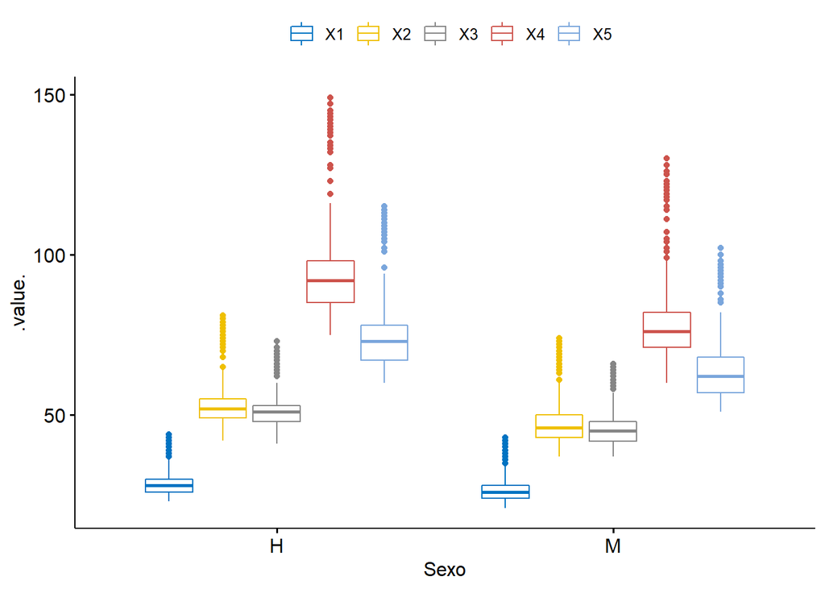

```r
ggboxplot(escarab, x = "Sexo",y = c("X1", "X2", "X3", "X4", "X5"), merge = T, palette = "jco")
```

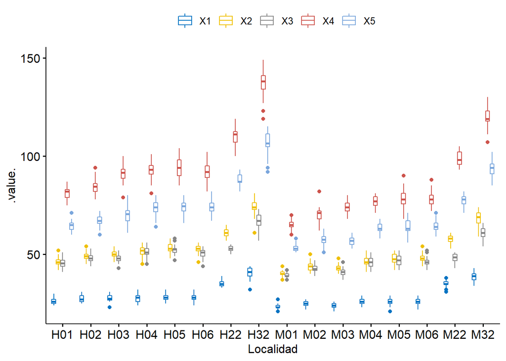

```r
ggboxplot(escarab, x = "Localidad",y = c("X1", "X2", "X3", "X4", "X5"), merge = T, palette = "jco")
```

### Cálculo estadístico

```r
aggregate(escarab[,1:5], list(escarab$Sexo, escarab$Localidad), mean)
```

```
##    Group.1 Group.2       X1       X2     X3       X4        X5
## 1        H     H01 26.32500 46.32500 45.600  81.1500  64.60000
## 2        H     H02 27.45000 48.90000 47.950  84.3000  66.87500
## 3        H     H03 27.60000 50.20000 47.850  91.0000  70.10000
## 4        H     H04 27.87500 51.57500 51.075  92.9500  73.65000
## 5        H     H05 28.22500 53.05000 52.325  94.0500  74.10000
## 6        H     H06 27.92500 52.60000 50.575  91.8750  73.85000
## 7        H     H22 35.33333 61.13333 52.800 109.8667  88.00000
## 8        H     H32 40.55000 74.32500 66.800 137.2750 106.87500
## 9        M     M01 23.22500 40.17500 39.425  65.0750  53.57500
## 10       M     M02 24.82500 43.52500 42.500  70.0750  57.35000
## 11       M     M03 23.82500 43.07500 40.750  74.0000  56.77500
## 12       M     M04 25.95000 46.62500 46.150  76.9000  63.47500
## 13       M     M05 25.60000 47.52500 46.725  78.6000  64.02500
## 14       M     M06 25.80000 47.95000 46.275  78.4000  64.37500
## 15       M     M22 35.08333 57.50000 48.125  98.8750  77.29167
## 16       M     M32 38.90000 68.60000 61.050 119.6750  93.72500
```

```r
aggregate(escarab[,1:5], list(escarab$Sexo, escarab$Localidad), length)
```

```
##    Group.1 Group.2 X1 X2 X3 X4 X5
## 1        H     H01 40 40 40 40 40
## 2        H     H02 40 40 40 40 40
## 3        H     H03 20 20 20 20 20
## 4        H     H04 40 40 40 40 40
## 5        H     H05 40 40 40 40 40
## 6        H     H06 40 40 40 40 40
## 7        H     H22 15 15 15 15 15
## 8        H     H32 40 40 40 40 40
## 9        M     M01 40 40 40 40 40
## 10       M     M02 40 40 40 40 40
## 11       M     M03 40 40 40 40 40
## 12       M     M04 40 40 40 40 40
## 13       M     M05 40 40 40 40 40
## 14       M     M06 40 40 40 40 40
## 15       M     M22 24 24 24 24 24
## 16       M     M32 40 40 40 40 40
```

```r
aggregate(escarab[,1:5], list(escarab$Sexo, escarab$Localidad), sd)
```

```
##    Group.1 Group.2       X1       X2       X3       X4       X5
## 1        H     H01 1.525636 2.116934 2.216488 3.254583 2.734396
## 2        H     H02 1.535060 2.073026 2.123736 3.306559 2.662055
## 3        H     H03 1.818038 2.284962 2.412140 4.823190 4.564162
## 4        H     H04 1.785806 2.836461 2.595731 3.928528 3.512250
## 5        H     H05 1.560531 2.561550 2.555913 4.657225 2.968208
## 6        H     H06 1.802953 2.216488 2.182536 4.767344 3.548564
## 7        H     H22 1.799471 2.445599 1.320173 5.111146 3.359422
## 8        H     H32 2.469818 4.015275 3.405877 6.072162 5.321401
## 9        M     M01 1.025008 1.337573 1.059451 2.346711 1.737778
## 10       M     M02 1.318264 2.148195 1.894662 3.716819 2.496664
## 11       M     M03 1.238020 1.913347 1.877669 2.828427 2.325858
## 12       M     M04 1.568112 2.477463 2.465662 2.715577 2.707894
## 13       M     M05 1.629850 2.601651 2.782615 4.447990 3.497160
## 14       M     M06 1.453554 1.973543 2.025320 3.535897 2.588807
## 15       M     M22 1.585715 2.359071 2.437256 3.802888 3.085438
## 16       M     M32 2.048139 3.232844 2.620922 4.570740 3.902580
```

### Normalidad univariada

```r
normal <- function(vec){
  shapiro.test(vec)$p
}
aggregate(escarab[,1:5], list(escarab$Sexo, escarab$Localidad), normal)
```

```
##    Group.1 Group.2           X1         X2          X3         X4          X5
## 1        H     H01 0.0297702819 0.26435483 0.450693146 0.23124027 0.049318988
## 2        H     H02 0.0065503542 0.32552138 0.348866435 0.07173097 0.458858738
## 3        H     H03 0.3659550850 0.39307879 0.157547416 0.79091493 0.935985020
## 4        H     H04 0.2364854536 0.10602080 0.145446896 0.27223361 0.105071979
## 5        H     H05 0.1260575658 0.32289438 0.163094288 0.47456114 0.288229204
## 6        H     H06 0.1093276109 0.06070347 0.034042083 0.85413865 0.315986617
## 7        H     H22 0.3500652908 0.69603661 0.441588361 0.90423456 0.602308051
## 8        H     H32 0.0049963913 0.04828909 0.245492520 0.07518613 0.016935415
## 9        M     M01 0.0001075424 0.02593972 0.003074658 0.39534293 0.001178111
## 10       M     M02 0.0043071563 0.06141016 0.218785823 0.03257806 0.362695280
## 11       M     M03 0.0245109250 0.04164210 0.211803891 0.57638147 0.119939903
## 12       M     M04 0.0328036643 0.22543521 0.396152982 0.10475221 0.079936861
## 13       M     M05 0.0214347088 0.21038692 0.225150878 0.23957808 0.237464850
## 14       M     M06 0.0447452265 0.01414083 0.129814321 0.10488247 0.377056928
## 15       M     M22 0.0866344287 0.14475598 0.011822846 0.12095759 0.219433112
## 16       M     M32 0.1324521568 0.15057425 0.258691257 0.48923326 0.260977540
```

### Normalidad Multiple

```r
mvn(escarab[ , c(1,2,3,4,5)], mvnTest = "hz")
```

```
## $multivariateNormality
##            Test       HZ p value MVN
## 1 Henze-Zirkler 5.299424       0  NO
##
## $univariateNormality
##           Test  Variable Statistic   p value Normality
## 1 Shapiro-Wilk    X1        0.8425  <0.001      NO
## 2 Shapiro-Wilk    X2        0.8772  <0.001      NO
## 3 Shapiro-Wilk    X3        0.9189  <0.001      NO
## 4 Shapiro-Wilk    X4        0.8938  <0.001      NO
## 5 Shapiro-Wilk    X5        0.8917  <0.001      NO
##
## $Descriptives
##      n     Mean   Std.Dev Median Min Max 25th 75th     Skew  Kurtosis
## X1 579 28.64076  5.440346     27  21  44   25   30 1.218632 0.4522992
## X2 579 51.59067  9.521964     49  37  81   45   54 1.213785 0.8228964
## X3 579 49.03627  7.435331     48  37  73   44   52 1.024961 0.7852596
## X4 579 89.14335 19.295512     84  60 149   76   96 1.154392 0.7860613
## X5 579 70.99655 14.430240     67  51 115   61   76 1.169971 0.8522085
```

### Pruebas de varianzas y covarianzas

```r
boxM(data = escarab[,c(1,2,3,4,5)], grouping = escarab$Sexo)
```

```
##
##  Box's M-test for Homogeneity of Covariance Matrices
##
## data:  escarab[, c(1, 2, 3, 4, 5)]
## Chi-Sq (approx.) = 99.779, df = 15, p-value = 1.437e-14
```

```r
boxM(data = escarab[,c(1,2,3,4,5)], grouping = escarab$Localidad)
```

```
##
##  Box's M-test for Homogeneity of Covariance Matrices
##
## data:  escarab[, c(1, 2, 3, 4, 5)]
## Chi-Sq (approx.) = 508.15, df = 225, p-value < 2.2e-16
```

```r
leveneTest(X1~Sexo, escarab)
```

```
## Levene's Test for Homogeneity of Variance (center = median)
##        Df F value Pr(>F)
## group   1  0.7922 0.3738
##       577
```

```r
leveneTest(X1~Localidad, escarab)
```

```
## Levene's Test for Homogeneity of Variance (center = median)
##        Df F value    Pr(>F)
## group  15  2.6716 0.0006076 ***
##       563
## ---
## Signif. codes:  0 '***' 0.001 '**' 0.01 '*' 0.05 '.' 0.1 ' ' 1
```

```r
leveneTest(X2~Sexo, escarab)
```

```
## Levene's Test for Homogeneity of Variance (center = median)
##        Df F value Pr(>F)
## group   1  0.0942  0.759
##       577
```

```r
leveneTest(X2~Localidad, escarab)
```

```
## Levene's Test for Homogeneity of Variance (center = median)
##        Df F value    Pr(>F)
## group  15  3.3799 1.688e-05 ***
##       563
## ---
## Signif. codes:  0 '***' 0.001 '**' 0.01 '*' 0.05 '.' 0.1 ' ' 1
```

```r
leveneTest(X3~Sexo, escarab)
```

```
## Levene's Test for Homogeneity of Variance (center = median)
##        Df F value Pr(>F)
## group   1  0.1385 0.7099
##       577
```

```r
leveneTest(X3~Localidad, escarab)
```

```
## Levene's Test for Homogeneity of Variance (center = median)
##        Df F value    Pr(>F)
## group  15  3.2591 3.158e-05 ***
##       563
## ---
## Signif. codes:  0 '***' 0.001 '**' 0.01 '*' 0.05 '.' 0.1 ' ' 1
```

```r
leveneTest(X4~Sexo, escarab)
```

```
## Levene's Test for Homogeneity of Variance (center = median)
##        Df F value Pr(>F)
## group   1  0.3833 0.5361
##       577
```

```r
leveneTest(X4~Localidad, escarab)
```

```
## Levene's Test for Homogeneity of Variance (center = median)
##        Df F value    Pr(>F)
## group  15  2.9318 0.0001674 ***
##       563
## ---
## Signif. codes:  0 '***' 0.001 '**' 0.01 '*' 0.05 '.' 0.1 ' ' 1
```

```r
leveneTest(X5~Sexo, escarab)
```

```
## Levene's Test for Homogeneity of Variance (center = median)
##        Df F value Pr(>F)
## group   1  0.3096 0.5781
##       577
```

```r
leveneTest(X5~Localidad, escarab)
```

```
## Levene's Test for Homogeneity of Variance (center = median)
##        Df F value    Pr(>F)
## group  15  3.6128 4.979e-06 ***
##       563
## ---
## Signif. codes:  0 '***' 0.001 '**' 0.01 '*' 0.05 '.' 0.1 ' ' 1
```

### Modelo Manova

```r
mod1 <- manova(cbind(X1, X2, X3, X4, X5)~Sexo+Localidad, data = escarab)
summary(mod1)
```

```
##            Df  Pillai approx F num Df den Df    Pr(>F)
## Sexo        1 0.82245   517.90      5    559 < 2.2e-16 ***
## Localidad  14 2.26063    33.19     70   2815 < 2.2e-16 ***
## Residuals 563
## ---
## Signif. codes:  0 '***' 0.001 '**' 0.01 '*' 0.05 '.' 0.1 ' ' 1
```

#### modelo con interacción

```r
mod2 <- manova(cbind(X1, X2, X3, X4, X5)~Sexo*Localidad, data = escarab)
summary(mod2)
```

```
##            Df  Pillai approx F num Df den Df    Pr(>F)
## Sexo        1 0.82245   517.90      5    559 < 2.2e-16 ***
## Localidad  14 2.26063    33.19     70   2815 < 2.2e-16 ***
## Residuals 563
## ---
## Signif. codes:  0 '***' 0.001 '**' 0.01 '*' 0.05 '.' 0.1 ' ' 1
```

### Modelos univariados

```r
m1 <- aov(X1~Localidad, data=escarab)
summary(m1)
```

```
##              Df Sum Sq Mean Sq F value Pr(>F)
## Localidad    15  15561  1037.4   377.6 <2e-16 ***
## Residuals   563   1547     2.7
## ---
## Signif. codes:  0 '***' 0.001 '**' 0.01 '*' 0.05 '.' 0.1 ' ' 1
```

```r
m2 <- aov(X2~Localidad, data=escarab)
summary(m2)
```

```
##              Df Sum Sq Mean Sq F value Pr(>F)
## Localidad    15  48907    3260   524.7 <2e-16 ***
## Residuals   563   3499       6
## ---
## Signif. codes:  0 '***' 0.001 '**' 0.01 '*' 0.05 '.' 0.1 ' ' 1
```

```r
m3 <- aov(X3~Localidad, data=escarab)
summary(m3)
```

```
##              Df Sum Sq Mean Sq F value Pr(>F)
## Localidad    15  28871  1924.7   351.5 <2e-16 ***
## Residuals   563   3083     5.5
## ---
## Signif. codes:  0 '***' 0.001 '**' 0.01 '*' 0.05 '.' 0.1 ' ' 1
```

```r
m4 <- aov(X4~Localidad, data=escarab)
summary(m4)
```

```
##              Df Sum Sq Mean Sq F value Pr(>F)
## Localidad    15 206020   13735   842.4 <2e-16 ***
## Residuals   563   9179      16
## ---
## Signif. codes:  0 '***' 0.001 '**' 0.01 '*' 0.05 '.' 0.1 ' ' 1
```

```r
m5 <- aov(X5~Localidad, data=escarab)
summary(m5)
```

```
##              Df Sum Sq Mean Sq F value Pr(>F)
## Localidad    15 114407    7627   721.6 <2e-16 ***
## Residuals   563   5951      11
## ---
## Signif. codes:  0 '***' 0.001 '**' 0.01 '*' 0.05 '.' 0.1 ' ' 1
```

```r
m6 <- aov(X1~Localidad*Sexo, data=escarab)
summary(m6)
```

```
##              Df Sum Sq Mean Sq F value Pr(>F)
## Localidad    15  15561  1037.4   377.6 <2e-16 ***
## Residuals   563   1547     2.7
## ---
## Signif. codes:  0 '***' 0.001 '**' 0.01 '*' 0.05 '.' 0.1 ' ' 1
```

```r
m7 <- aov(X2~Localidad*Sexo, data=escarab)
summary(m7)
```

```
##              Df Sum Sq Mean Sq F value Pr(>F)
## Localidad    15  48907    3260   524.7 <2e-16 ***
## Residuals   563   3499       6
## ---
## Signif. codes:  0 '***' 0.001 '**' 0.01 '*' 0.05 '.' 0.1 ' ' 1
```

```r
m8 <- aov(X3~Localidad*Sexo, data=escarab)
summary(m8)
```

```
##              Df Sum Sq Mean Sq F value Pr(>F)
## Localidad    15  28871  1924.7   351.5 <2e-16 ***
## Residuals   563   3083     5.5
## ---
## Signif. codes:  0 '***' 0.001 '**' 0.01 '*' 0.05 '.' 0.1 ' ' 1
```

```r
m9 <- aov(X2~Localidad*Sexo, data=escarab)
summary(m9)
```

```
##              Df Sum Sq Mean Sq F value Pr(>F)
## Localidad    15  48907    3260   524.7 <2e-16 ***
## Residuals   563   3499       6
## ---
## Signif. codes:  0 '***' 0.001 '**' 0.01 '*' 0.05 '.' 0.1 ' ' 1
```

```r
m10 <- aov(X3~Localidad*Sexo, data=escarab)
summary(m10)
```

```
##              Df Sum Sq Mean Sq F value Pr(>F)
## Localidad    15  28871  1924.7   351.5 <2e-16 ***
## Residuals   563   3083     5.5
## ---
## Signif. codes:  0 '***' 0.001 '**' 0.01 '*' 0.05 '.' 0.1 ' ' 1
```

### análisis post hoc

```r
etaSquared(m1)
```

```
##              eta.sq eta.sq.part
## Localidad 0.9095887   0.9095887
```

```r
etaSquared(m2)
```

```
##              eta.sq eta.sq.part
## Localidad 0.9332379   0.9332379
```

```r
etaSquared(m3)
```

```
##              eta.sq eta.sq.part
## Localidad 0.9035175   0.9035175
```

```r
etaSquared(m4)
```

```
##              eta.sq eta.sq.part
## Localidad 0.9573459   0.9573459
```

```r
etaSquared(m5)
```

```
##              eta.sq eta.sq.part
## Localidad 0.9505554   0.9505554
```

```r
etaSquared(m6)
```

```
##                   eta.sq eta.sq.part
## Localidad      0.8628458   0.9051554
## Sexo           0.0000000   0.0000000
## Localidad:Sexo 0.0000000   0.0000000
```

```r
etaSquared(m7)
```

```
##                   eta.sq eta.sq.part
## Localidad      0.8476892   0.9269922
## Sexo           0.0000000   0.0000000
## Localidad:Sexo 0.0000000   0.0000000
```

```r
etaSquared(m8)
```

```
##                   eta.sq eta.sq.part
## Localidad      0.7516651   0.8862433
## Sexo           0.0000000   0.0000000
## Localidad:Sexo 0.0000000   0.0000000
```

```r
etaSquared(m9)
```

```
##                   eta.sq eta.sq.part
## Localidad      0.8476892   0.9269922
## Sexo           0.0000000   0.0000000
## Localidad:Sexo 0.0000000   0.0000000
```

```r
etaSquared(m10)
```

```
##                   eta.sq eta.sq.part
## Localidad      0.7516651   0.8862433
## Sexo           0.0000000   0.0000000
## Localidad:Sexo 0.0000000   0.0000000
```

```r
post <- TukeyHSD(m1)
post
```

```
##   Tukey multiple comparisons of means
##     95% family-wise confidence level
##
## Fit: aov(formula = X1 ~ Localidad, data = escarab)
##
## $Localidad
##               diff         lwr          upr     p adj
## H02-H01   1.125000  -0.1505919   2.40059192 0.1577160
## H03-H01   1.275000  -0.2872747   2.83727467 0.2669596
## H04-H01   1.550000   0.2744081   2.82559192 0.0034534
## H05-H01   1.900000   0.6244081   3.17559192 0.0000470
## H06-H01   1.600000   0.3244081   2.87559192 0.0019779
## H22-H01   9.008333   7.2811737  10.73549296 0.0000000
## H32-H01  14.225000  12.9494081  15.50059192 0.0000000
## M01-H01  -3.100000  -4.3755919  -1.82440808 0.0000000
## M02-H01  -1.500000  -2.7755919  -0.22440808 0.0059078
## M03-H01  -2.500000  -3.7755919  -1.22440808 0.0000000
## M04-H01  -0.375000  -1.6505919   0.90059192 0.9997666
## M05-H01  -0.725000  -2.0005919   0.55059192 0.8479923
## M06-H01  -0.525000  -1.8005919   0.75059192 0.9898505
## M22-H01   8.758333   7.2854067  10.23126001 0.0000000
## M32-H01  12.575000  11.2994081  13.85059192 0.0000000
## H03-H02   0.150000  -1.4122747   1.71227467 1.0000000
## H04-H02   0.425000  -0.8505919   1.70059192 0.9989641
## H05-H02   0.775000  -0.5005919   2.05059192 0.7702787
## H06-H02   0.475000  -0.8005919   1.75059192 0.9964113
## H22-H02   7.883333   6.1561737   9.61049296 0.0000000
## H32-H02  13.100000  11.8244081  14.37559192 0.0000000
## M01-H02  -4.225000  -5.5005919  -2.94940808 0.0000000
## M02-H02  -2.625000  -3.9005919  -1.34940808 0.0000000
## M03-H02  -3.625000  -4.9005919  -2.34940808 0.0000000
## M04-H02  -1.500000  -2.7755919  -0.22440808 0.0059078
## M05-H02  -1.850000  -3.1255919  -0.57440808 0.0000917
## M06-H02  -1.650000  -2.9255919  -0.37440808 0.0011106
## M22-H02   7.633333   6.1604067   9.10626001 0.0000000
## M32-H02  11.450000  10.1744081  12.72559192 0.0000000
## H04-H03   0.275000  -1.2872747   1.83727467 0.9999997
## H05-H03   0.625000  -0.9372747   2.18727467 0.9923792
## H06-H03   0.325000  -1.2372747   1.88727467 0.9999974
## H22-H03   7.733333   5.7848345   9.68183218 0.0000000
```

[output cut: 72 more lines]

```
## M04-M03   2.125000   0.8494081   3.40059192 0.0000019
## M05-M03   1.775000   0.4994081   3.05059192 0.0002416
## M06-M03   1.975000   0.6994081   3.25059192 0.0000167
## M22-M03  11.258333   9.7854067  12.73126001 0.0000000
## M32-M03  15.075000  13.7994081  16.35059192 0.0000000
## M05-M04  -0.350000  -1.6255919   0.92559192 0.9999009
## M06-M04  -0.150000  -1.4255919   1.12559192 1.0000000
## M22-M04   9.133333   7.6604067  10.60626001 0.0000000
## M32-M04  12.950000  11.6744081  14.22559192 0.0000000
## M06-M05   0.200000  -1.0755919   1.47559192 0.9999999
## M22-M05   9.483333   8.0104067  10.95626001 0.0000000
## M32-M05  13.300000  12.0244081  14.57559192 0.0000000
## M22-M06   9.283333   7.8104067  10.75626001 0.0000000
## M32-M06  13.100000  11.8244081  14.37559192 0.0000000
## M32-M22   3.816667   2.3437400   5.28959335 0.0000000
```

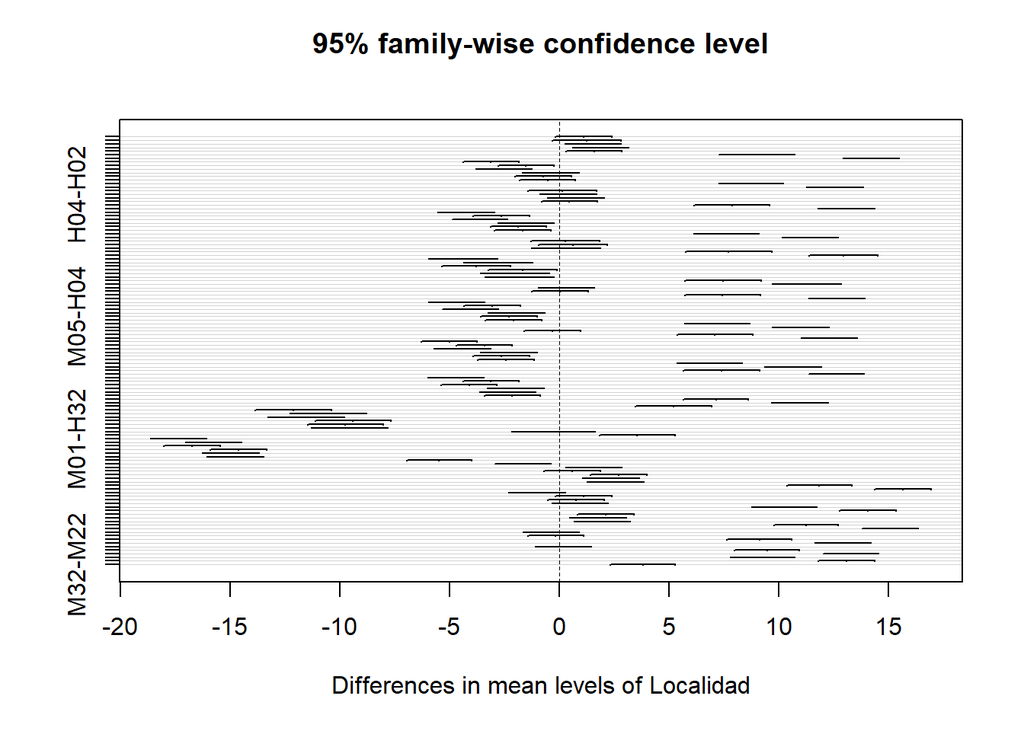

```r
plot(post)
```